# How to make a chart in ggplot2?

# A geom_ribbon() geometry - a band chart

The last example in this episode will be a `geom_ribbon()` geometry used for drawing the ribbon.

It is such an interesting example because it requires indication of other characteristics than `y`, as the ribbons are described by a interval, namely `ymin` and `ymax` characteristics. Each of these features can be combined with a variable or ascribed a constant value.

Using the example below, we draw the band extending from zero (constant value `ymin=0`) to the value of `WIG` (`ymax=Kurs.zamkniecia`).

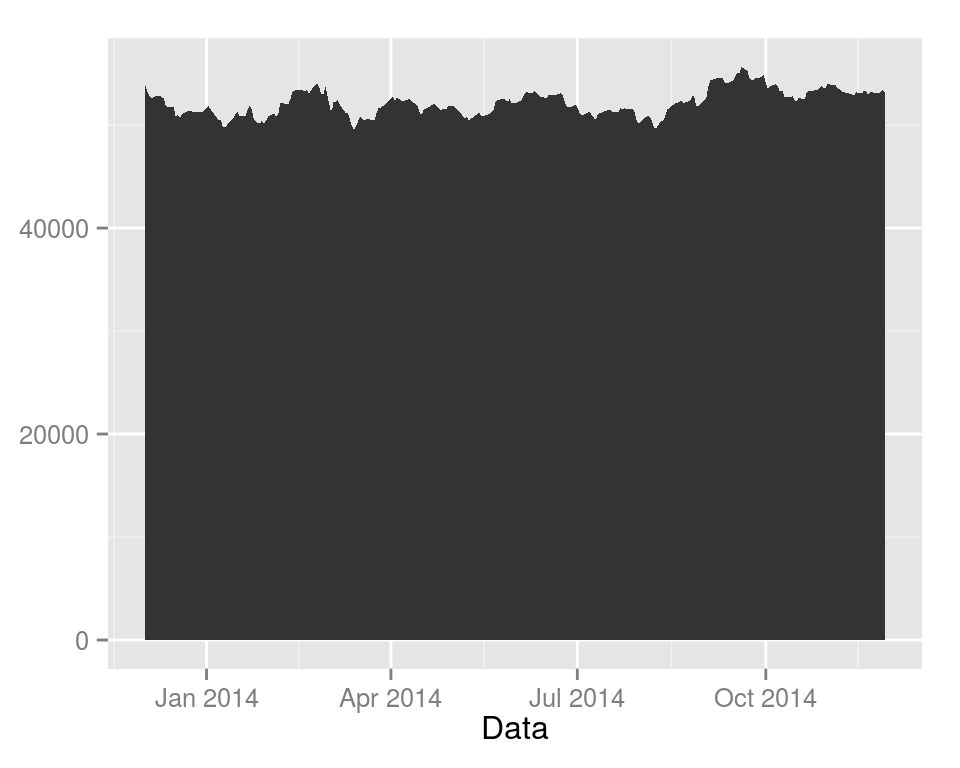

```r
ggplot(WIG, aes(x=Data, ymin=0, ymax=Kurs.zamkniecia)) +
  geom_ribbon()
```

# Where to search for further information

We have mastered the basis of chart creating with the use of ggplot2 package. In the subsequent episodes we will present you more information, but they can also be found in the following sources.

- Very interesting presentation on designing the charts, named *Figure Design* is available at http://www.bioinformatics.babraham.ac.uk/training/Figure%20Design%20Course%20Presentation.pdf
- More information concerning charts creation with the ggplot2 packet can be found in Chapter 4 of *“Przewodnik po pakiecie R”*. For more information on this book http://www.biecek.pl/R/
- Many useful instructions can also be found in an e-book *“CookBook for R”* http://www.cookbook-r.com/Graphs/
- Very extensive documentation of ggplot2 packet is available on the *“ggplot2”* website. http://docs.ggplot2.org/current/index.html
- Nothing, however, will replace own experiments with creation of the charts. If something isn’t working as it should, you can ask for help on the forum of this course or on the Internet, e.g. on forum http://stats.stackexchange.com/.

# Exercises:

- Using a point chart present the relation between longevity (`zywotnosc` column) and animal weight (`waga` column).
- Mark with the colour or shape of a point the information whether a bird or cat is presented. What are the differences between life span and weight for cats and birds?
- Use labels to determine which bird and which cat have the higher longevity.
- Using ribbon geometry (`geom_ribbon`) present a minimum and maximum exchange rate for each day on the basis of the data from `WIG` dataset.

Sample answers are available on the website https://rawgit.com/pbiecek/MOOC/master/0_dane/9_zadania_sezon2.html